# Part II - influences on student potential

## by Yaser Issa

## Investigation Overview

> In this presentation, I will be discussing the effect of wealth and socioeconomic status on grades. We will explore how these factors can influence a student's academic performance and how they can be addressed in order to ensure whether all students have an equal opportunity to succeed. After that, I'll do Wealth vs. Grade, with gender variations.

## Dataset Overview

The Programme for International Student Assessment ('PISA') is a global study conducted in member and non-member countries by the Organization for Economic Cooperation and Development to evaluate educational systems by measuring 15-year-old school pupils' scholastic performance in mathematics, science, and reading. and this dataset is the outcome of the 2012 study

## Wealth vs. socioeconomic status

```
0.68542229660592791
```

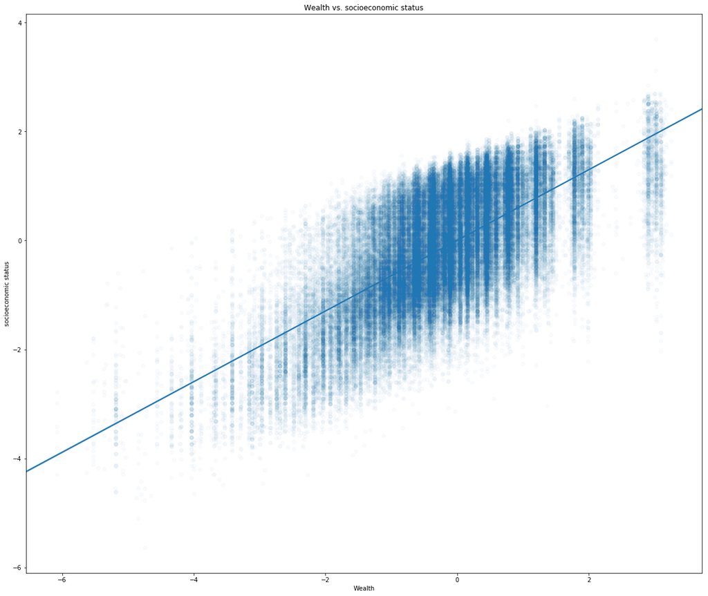

```python
plt.figure (figsize = [20,17])
sb.regplot(x= 'WEALTH', y='Socio_economic_status', data = pisa, color =base_color, scatter_kws={'alpha':1/40} );
plt.xlabel('Wealth')
plt.ylabel('socioeconomic status')
plt.title('Wealth vs. socioeconomic status')
pisa['WEALTH'].corr(pisa['Socio_economic_status'])
```

## Wealth vs. grades

> The relationship between wealth and grades is comparatively negligible, as indicated by a pearson correlation score of roughly 0.0099701051668246148, indicating that they are not really directly proportional. Considering that socioeconomic status is positively correlated with wealth, this is also the solution.

```
0.0099701051668246148
```

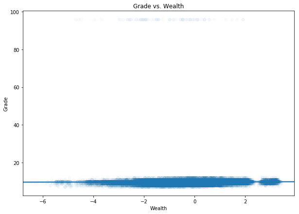

```python
plt.figure (figsize = [10,7])
sb.regplot(y= 'Grade', x='WEALTH', data = pisa, color =base_color, x_jitter=0.3, scatter_kws={'alpha':1/40});
plt.xlabel('Wealth')
plt.ylabel('Grade')
plt.title('Grade vs. Wealth')
pisa['WEALTH'].corr(pisa['Grade'])
```

## Wealth vs. grade varying by gender

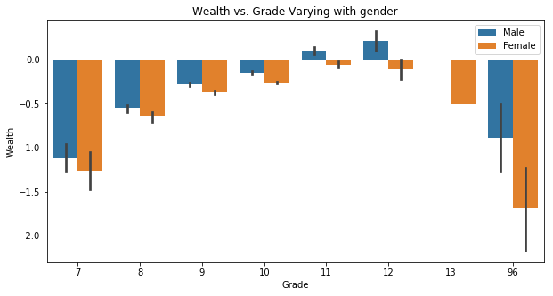

```python
plt.figure(figsize = [10, 5])
sb.barplot(data=pisa, x='Grade', y='WEALTH', hue= 'Gender');
plt.xlabel('Grade')
plt.ylabel('Wealth')
plt.title('Wealth vs. Grade Varying with gender')
plt.legend()
```